# Unidad 4: Importar y exportar datos

Rubén Muñoz

2024-01-27

## **Bienvenida**

En esta lección aprederemos cómo podemos **importar** y **exportar** datos. Principalmente en formato *.csv* y *.txt*, los cuales son los formatos generales donde guardamos nuestros datos o se ponen a disposición de las personas. :)

[figure not shown]

Cute Kitty using R

## **Directorio de trabajo**

Un directorio de trabajo es una carpeta con una ruta en nuestro dispositivo en el que se alojan los archivos que usaremos y guardaremos para un trabajo o análisis. Podemos entrar y salir del directotio siempre que queramos.

### Conocer directorio actual `getwd()`

Con la función `getwd()` al abrir R podemos saber qué directorio estamos usando. Sólo debemos escribirla y nos dirá la ruta.

```r
getwd()
```

### Definir directorio

Con la función `setwd("C:/rutaDelDirectorio")` podemos definir un directorio específico para trabajar. Es importante colocar la ruta entre comillas para que R la reconozca correctamente. También se puede definir el directorio de trabajo en la interfaz de RStudio. Para ello sólo es necesario ir a la barra superior de opciones en el apartado `Session>Set working directory>Choose Diretory` (ver Imagen)

[figure not shown]

Establecer un working directory en R (directorio de trabajo)

Una vez ahí seleccionaremos la carpeta donde queremos importar o exportar los datos. (Nota: Es buena idea tener carpetas ordenadas sin nombres muy complejos ni caracteres especiales)

## **Leer archivos: *.csv*, *.txt***

Para leer archivos usamos la función `read."formato"("./rutaDelArchivo.formato")`. En el caso de que queramos leer un csv usamos la función `read.csv()`. Ejemplo:

```r
# Usamos un archivo presente en mi directorio de trabajo

 read.csv("baseEjemploRanitas.csv")
```

Con un archivo *.txt* usamos la función `read.table()` Al cargar archivos nuevos nos interesa almacenarlos en variables para seguirlos usando.

```r
# Es conveniente gurdarlo en una variable como cualquier otro objeto de R
 ranitas <- read.csv("baseEjemploRanitas.csv",
                     header = T ## Éste parámetro especifíca si tiene encabezado o no. De no tener le asigna un valor por defecto
                     #,row.names = 1 # Éste sirve para indicar que la primer columna es el nombre de los renglones
                     )

# Ahora podemos usar la función head() para ver qué contiene
 head(ranitas)
```

```
##                        Species Functional.group Body.size Leg.length
## 1       Gymnopis syntrema (De)              FG1        EL         NL
## 2   Smilisca cyanosticta (Hy5)              FG2         L         EL
## 3  Bolitoglossa mexicana (Pl1)              FG3         M          S
## 4   Bolitoglossa mulleri (Pl2)              FG3         M          M
## 5 Bolitoglossa rufescens (Pl3)              FG3         S          S
## 6      Oedipina elongata (Pl4)              FG3         M          S
##   Respiration.type Fertilization.type
## 1             Lung                Int
## 2             Lung                Ext
## 3             Skin                Int
## 4             Skin                Int
## 5             Skin                Int
## 6             Skin                Int
```

```r
# Son características de ranitas, salamandras y cecilias tomadas para un artículo.
```

## **Acceso a archivos cargados**

Para ver el archivo es tan simple como escribir el nombre de la variable donde guardamos el archivo para que se imprima en la consola. Sin embarrgo en **RStudio** se puede hacer hacienco click dos veces sobre el objeto en el apartado de **Data** ubicado a la derecha de la interfaz de RStudio.

[figure not shown]

Data

Al hacer click nos enviará hacia un visualizador donde observaremos nuestros datos y sabremos cuántos registros tiene ,así como, ordenarlos en orden alfabético, etc. Nota: esto no afectará nuestro arcvhivo orginal, sólo es para visualizarse.

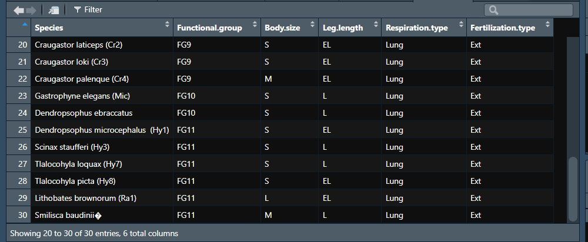

CSV leído

### Exploración básica

Al archivo cargado podemos aplicarle diferentes funciones para saber sobre éste. Podemos iniciar con:

```r
#Para ver sus primeros datos
 head(ranitas)
```

```
##                        Species Functional.group Body.size Leg.length
## 1       Gymnopis syntrema (De)              FG1        EL         NL
## 2   Smilisca cyanosticta (Hy5)              FG2         L         EL
## 3  Bolitoglossa mexicana (Pl1)              FG3         M          S
## 4   Bolitoglossa mulleri (Pl2)              FG3         M          M
## 5 Bolitoglossa rufescens (Pl3)              FG3         S          S
## 6      Oedipina elongata (Pl4)              FG3         M          S
##   Respiration.type Fertilization.type
## 1             Lung                Int
## 2             Lung                Ext
## 3             Skin                Int
## 4             Skin                Int
## 5             Skin                Int
## 6             Skin                Int
```

```r
# Para un resumen del objeto: Longitud, Clase, Nombre de los campos, etc.
 summary(ranitas)
```

```
##    Species          Functional.group    Body.size          Leg.length
##  Length:30          Length:30          Length:30          Length:30
##  Class :character   Class :character   Class :character   Class :character
##  Mode  :character   Mode  :character   Mode  :character   Mode  :character
##  Respiration.type   Fertilization.type
##  Length:30          Length:30
##  Class :character   Class :character
##  Mode  :character   Mode  :character
```

```r
# Para saber el nombre de las columnas
 colnames(ranitas) #Columnas
```

```
## [1] "Species"            "Functional.group"   "Body.size"
## [4] "Leg.length"         "Respiration.type"   "Fertilization.type"
```

```r
 rownames(ranitas) #Renglones
```

```
##  [1] "1"  "2"  "3"  "4"  "5"  "6"  "7"  "8"  "9"  "10" "11" "12" "13" "14" "15"
## [16] "16" "17" "18" "19" "20" "21" "22" "23" "24" "25" "26" "27" "28" "29" "30"
```

```r
# Para conocer el nombre de las especies
 table(ranitas$Species)
```

```
##
##              Smilisca baudinii\xa0 Hyalinobatrachium fleischmanni\xa0
##                                  1                                  1
##        Agalychnis callidryas (Phy)        Bolitoglossa mexicana (Pl1)
##                                  1                                  1
##         Bolitoglossa mulleri (Pl2)       Bolitoglossa rufescens (Pl3)
##                                  1                                  1
##           Craugastor alfredi (Cr1)          Craugastor laticeps (Cr2)
##                                  1                                  1
##              Craugastor loki (Cr3)          Craugastor palenque (Cr4)
##                                  1                                  1
##           Dendropsophus ebraccatus Dendropsophus microcephalus  (Hy1)
##                                  1                                  1
##      Eleutherodactylus leprus (El)          Gastrophyne elegans (Mic)
##                                  1                                  1
##             Gymnopis syntrema (De)           Incilius campbelli (Bu1)
##                                  1                                  1
##           Incilius valliceps (Bu2)       Leptodactylus fragilis (Le1)
##                                  1                                  1
##    Leptodactylus melanonotus (Le2)         Lithobates brownorum (Ra1)
##                                  1                                  1
##         Lithobates maculatus (Ra2)         Lithobates vaillanti (Ra1)
##                                  1                                  1
##            Oedipina elongata (Pl4)          Rhinella horribilis (Bu3)
##                                  1                                  1
##        Rhinophrynus dorsalis (Rhi)             Scinax staufferi (Hy3)
##                                  1                                  1
##         Smilisca cyanosticta (Hy5)           Tlalocohyla loquax (Hy7)
##                                  1                                  1
##            Tlalocohyla picta (Hy8)     Trachycephalus typhonius (Hy6)
##                                  1                                  1
```

## **Exportar datos**

Para exportar nuestros datos usamos la función `write.csv()` o `write.table()`. R funciona como convertidor de formato por lo que si originalmente nuestro archivo era *.csv* podemos guardarlo como *.txt* Ejemplo:

```r
# Aquí pasamos de un .csv a un .txt
write.table(ranitas, ## Objeto a guardar
            file = "ranitasEjemploTexto.txt" ## Aquí podemos poner la ruta, si no sólo se guardará en el directorio actual
            ## sep = "Hola" #Con lo que separará
            ## row.names = "" Aquí podemos indicar si los valores de la primer columna servirán para darle nombre a los renglones
            ## col.names = Nombre de las columnas
            )
```

##### **Terminamos con la Unidad 4 ¡Felicidades!**